# 1. Import drug screen data

gDR team

2026-10-07

1. Import drug screen data

**gDR Analysis Pipeline**

Date: 2026-10-07

Author: [gDR team](https://github.com/gdrplatform)

# 1 Introduction

This report covers the first step in the gDR analysis pipeline: importing raw data, adding descriptive metadata, and performing initial quality control (QC). The goal is to produce a clean, organized dataset that is ready for reliable dose-response analysis.

```r
library(qs2)
library(purrr)
library(data.table)
library(summarytools)
library(gDRutils)
library(gDRimport)
library(gDRcore)
library(gDR)
library(gDRplots)
```

```r
# get working directory path
wd <- getwd()
```

# 2 Key Output Files

This report generates several key files that are used in the subsequent steps of the gDR pipeline.

## 2.1 Data Annotation Files (in `data_annotation/` folder):

- **`drug_annotation.csv`:** An annotation file listing all unique drugs found in the data with their annotations.
- **`cell_line_annotation.csv`:** An annotation file listing all unique cell lines found in the data with their annotations.

## 2.2 Processed gDR Data (in `gDR_data/` folder):

- **`gDR_input.qs2`:** This is the primary output of Step 1. It is a single, cleaned, and annotated `data.table` in a ‘tidy’ format, ready to be used as the input for the ‘Step 2: Data Processing’ report.

# 3 Import Raw Data into gDR and Do Manual Cleanup

This step merges experimental information from three sources: the manifest (plate metadata), template files (well layouts), and raw data files (instrument readouts). This produces the initial raw dataset for the gDR pipeline.

## 3.1 Minimum Required Fields

For single-agent data, the following fields are essential for the gDR pipeline input:

- **Gnumber**: Unique identifier for the experiment.
- **clid**: Cell line identifier.
- **ReadoutValue**: Measurement value obtained.
- **Duration**: Duration of the experiment.

## 3.2 Additional Annotations

In addition to the minimum required fields, the data undergoes a transformation process where annotations are added. These annotations enhance the contextual understanding of the data and include:

- **For Cell Lines**: Information such as cell line name, primary tissue, doubling time, parental identifier, and subtype.
- **For Drugs**: Details about the drug, including its name and mechanism of action.

## 3.3 Annotation Guidelines

The process for annotating the data adheres to the guidelines specified in the gDR annotation documentation. Detailed guidelines and instructions can be found in the [gDR Annotation Documentation](https://github.com/gdrplatform/gDRcore/blob/main/vignettes/gDR-annotation.Rmd).

```r
#import data
manifest <- c(
  "raw_data/2021.01.13_P22_QCS-35615.manifest.xlsx"
)
treatment <- c(
  "raw_data/Project22.Dosing1.template.xlsx",
  "raw_data/Project22.Dosing10.template.xlsx",
  "raw_data/Project22.Dosing10combo.template.xlsx",
  "raw_data/Project22.Dosing11.template.xlsx",
  "raw_data/Project22.Dosing11combo.template.xlsx",
  "raw_data/Project22.Dosing12.template.xlsx",
  "raw_data/Project22.Dosing12combo.template.xlsx",
  "raw_data/Project22.Dosing13.template.xlsx",
  "raw_data/Project22.Dosing13combo.template.xlsx",
  "raw_data/Project22.Dosing14.template.xlsx",
  "raw_data/Project22.Dosing14combo.template.xlsx",
  "raw_data/Project22.Dosing15.template.xlsx",
  "raw_data/Project22.Dosing15combo.template.xlsx",
  "raw_data/Project22.Dosing16.template.xlsx",
  "raw_data/Project22.Dosing16combo.template.xlsx",
  "raw_data/Project22.Dosing17.template.xlsx",
  "raw_data/Project22.Dosing17combo.template.xlsx",
  "raw_data/Project22.Dosing18.template.xlsx",
  "raw_data/Project22.Dosing18combo.template.xlsx",
  "raw_data/Project22.Dosing19.template.xlsx",
  "raw_data/Project22.Dosing19combo.template.xlsx",
  "raw_data/Project22.Dosing1combo.template.xlsx",
  "raw_data/Project22.Dosing2.template.xlsx",
  "raw_data/Project22.Dosing20.template.xlsx",
  "raw_data/Project22.Dosing20combo.template.xlsx",
  "raw_data/Project22.Dosing21.template.xlsx",
  "raw_data/Project22.Dosing21combo.template.xlsx",
  "raw_data/Project22.Dosing22.template.xlsx",
  "raw_data/Project22.Dosing22combo.template.xlsx",
  "raw_data/Project22.Dosing23.template.xlsx",
  "raw_data/Project22.Dosing23combo.template.xlsx",
  "raw_data/Project22.Dosing24.template.xlsx",
  "raw_data/Project22.Dosing24combo.template.xlsx",
  "raw_data/Project22.Dosing25.template.xlsx",
  "raw_data/Project22.Dosing25combo.template.xlsx",
  "raw_data/Project22.Dosing26.template.xlsx",
  "raw_data/Project22.Dosing26combo.template.xlsx",
  "raw_data/Project22.Dosing27.template.xlsx",
  "raw_data/Project22.Dosing27combo.template.xlsx",
  "raw_data/Project22.Dosing28.template.xlsx",
  "raw_data/Project22.Dosing28combo.template.xlsx",
  "raw_data/Project22.Dosing29.template.xlsx",
  "raw_data/Project22.Dosing29combo.template.xlsx",
  "raw_data/Project22.Dosing2combo.template.xlsx",
  "raw_data/Project22.Dosing3.template.xlsx",
  "raw_data/Project22.Dosing30.template.xlsx",
  "raw_data/Project22.Dosing30combo.template.xlsx",
  "raw_data/Project22.Dosing31.template.xlsx",
  "raw_data/Project22.Dosing31combo.template.xlsx",
  "raw_data/Project22.Dosing32.template.xlsx",
  "raw_data/Project22.Dosing32combo.template.xlsx",
  "raw_data/Project22.Dosing33.template.xlsx",
  "raw_data/Project22.Dosing33combo.template.xlsx",
  "raw_data/Project22.Dosing34.template.xlsx",
  "raw_data/Project22.Dosing34combo.template.xlsx",
  "raw_data/Project22.Dosing35.template.xlsx",
  "raw_data/Project22.Dosing35combo.template.xlsx",
  "raw_data/Project22.Dosing3combo.template.xlsx",
  "raw_data/Project22.Dosing4.template.xlsx",
  "raw_data/Project22.Dosing4combo.template.xlsx",
  "raw_data/Project22.Dosing5.template.xlsx",
  "raw_data/Project22.Dosing5combo.template.xlsx",
  "raw_data/Project22.Dosing6.template.xlsx",
  "raw_data/Project22.Dosing6combo.template.xlsx",
  "raw_data/Project22.Dosing7.template.xlsx",
  "raw_data/Project22.Dosing7combo.template.xlsx",
  "raw_data/Project22.Dosing8.template.xlsx",
  "raw_data/Project22.Dosing8combo.template.xlsx",
  "raw_data/Project22.Dosing9.template.xlsx",
  "raw_data/Project22.Dosing9combo.template.xlsx"
)
raw_data <- c(
  "raw_data/C0112160D01.csv",
  "raw_data/C0112160D02.csv",
  "raw_data/C0112160D03.csv",
  "raw_data/C0112160D04.csv",
  "raw_data/C0112160D05.csv",
  "raw_data/C0112160D06.csv",
  "raw_data/C0112160D07.csv",
  "raw_data/C0112160D08.csv",
  "raw_data/C0112160D09.csv",
  "raw_data/C0112160D10.csv",
  "raw_data/C0112160D11.csv",
  "raw_data/C0112160D12.csv",
  "raw_data/C0112160D13.csv",
  "raw_data/C0112160D14.csv",
  "raw_data/C0112160D15.csv",
  "raw_data/C0112160D16.csv",
  "raw_data/C0112160D17.csv",
  "raw_data/C0112160D18.csv",
  "raw_data/C0112160D19.csv",
  "raw_data/C0112160D20.csv",
  "raw_data/C0112160D21.csv",
  "raw_data/C0112160D22.csv",
  "raw_data/C0112160D23.csv",
  "raw_data/C0112160D24.csv",
  "raw_data/C0112160D25.csv",
  "raw_data/C0112160D26.csv",
  "raw_data/C0112160D27.csv",
  "raw_data/C0112160D28.csv",
  "raw_data/C0112160D29.csv",
  "raw_data/C0112160D30.csv",
  "raw_data/C0112160D31.csv",
  "raw_data/C0112160D32.csv",
  "raw_data/C0112160D33.csv",
  "raw_data/C0112160D34.csv",
  "raw_data/C0112160D35.csv",
  "raw_data/C0312160D01.csv",
  "raw_data/C0312160D02.csv",
  "raw_data/C0312160D03.csv",
  "raw_data/C0312160D04.csv",
  "raw_data/C0312160D05.csv",
  "raw_data/C0312160D06.csv",
  "raw_data/C0312160D07.csv",
  "raw_data/C0312160D08.csv",
  "raw_data/C0312160D09.csv",
  "raw_data/C0312160D10.csv",
  "raw_data/C0312160D11.csv",
  "raw_data/C0312160D12.csv",
  "raw_data/C0312160D13.csv",
  "raw_data/C0312160D14.csv",
  "raw_data/C0312160D15.csv",
  "raw_data/C0312160D16.csv",
  "raw_data/C0312160D17.csv",
  "raw_data/C0312160D18.csv",
  "raw_data/C0312160D19.csv",
  "raw_data/C0312160D20.csv",
  "raw_data/C0312160D21.csv",
  "raw_data/C0312160D22.csv",
  "raw_data/C0312160D23.csv",
  "raw_data/C0312160D24.csv",
  "raw_data/C0312160D25.csv",
  "raw_data/C0312160D26.csv",
  "raw_data/C0312160D27.csv",
  "raw_data/C0312160D28.csv",
  "raw_data/C0312160D29.csv",
  "raw_data/C0312160D30.csv",
  "raw_data/C0312160D31.csv",
  "raw_data/C0312160D32.csv",
  "raw_data/C0312160D33.csv",
  "raw_data/C0312160D34.csv",
  "raw_data/C0312160D35.csv",
  "raw_data/C0501131D01.csv",
  "raw_data/C0501131D02.csv",
  "raw_data/C0501131D03.csv",
  "raw_data/C0501131D04.csv",
  "raw_data/C0501131D05.csv",
  "raw_data/C0501131D06.csv",
  "raw_data/C0501131D07.csv",
  "raw_data/C0501131D08.csv",
  "raw_data/C0501131D09.csv",
  "raw_data/C0501131D10.csv",
  "raw_data/C0501131D11.csv",
  "raw_data/C0501131D12.csv",
  "raw_data/C0501131D13.csv",
  "raw_data/C0501131D14.csv",
  "raw_data/C0501131D15.csv",
  "raw_data/C0501131D16.csv",
  "raw_data/C0501131D17.csv",
  "raw_data/C0501131D18.csv",
  "raw_data/C0501131D19.csv",
  "raw_data/C0501131D20.csv",
  "raw_data/C0501131D21.csv",
  "raw_data/C0501131D22.csv",
  "raw_data/C0501131D23.csv",
  "raw_data/C0501131D24.csv",
  "raw_data/C0501131D25.csv",
  "raw_data/C0501131D26.csv",
  "raw_data/C0501131D27.csv",
  "raw_data/C0501131D28.csv",
  "raw_data/C0501131D29.csv",
  "raw_data/C0501131D30.csv",
  "raw_data/C0501131D31.csv",
  "raw_data/C0501131D32.csv",
  "raw_data/C0501131D33.csv",
  "raw_data/C0501131D34.csv",
  "raw_data/C0501131D35.csv",
  "raw_data/C0701131D01.csv",
  "raw_data/C0701131D02.csv",
  "raw_data/C0701131D03.csv",
  "raw_data/C0701131D04.csv",
  "raw_data/C0701131D05.csv",
  "raw_data/C0701131D06.csv",
  "raw_data/C0701131D07.csv",
  "raw_data/C0701131D08.csv",
  "raw_data/C0701131D09.csv",
  "raw_data/C0701131D10.csv",
  "raw_data/C0701131D11.csv",
  "raw_data/C0701131D12.csv",
  "raw_data/C0701131D13.csv",
  "raw_data/C0701131D14.csv",
  "raw_data/C0701131D15.csv",
  "raw_data/C0701131D16.csv",
  "raw_data/C0701131D17.csv",
  "raw_data/C0701131D18.csv",
  "raw_data/C0701131D19.csv",
  "raw_data/C0701131D20.csv",
  "raw_data/C0701131D21.csv",
  "raw_data/C0701131D22.csv",
  "raw_data/C0701131D23.csv",
  "raw_data/C0701131D24.csv",
  "raw_data/C0701131D25.csv",
  "raw_data/C0701131D26.csv",
  "raw_data/C0701131D27.csv",
  "raw_data/C0701131D28.csv",
  "raw_data/C0701131D29.csv",
  "raw_data/C0701131D30.csv",
  "raw_data/C0701131D31.csv",
  "raw_data/C0701131D32.csv",
  "raw_data/C0701131D33.csv",
  "raw_data/C0701131D34.csv",
  "raw_data/C0701131D35.csv"
)

# copy files to raw_data
for (file_path in c(manifest, treatment, raw_data)) {
  file_name <- basename(file_path)  # Extract the filename from the path
  file.copy(file_path, file.path(wd, "raw_data", file_name))
}

# load annotations
drug_annotation <- fread(file.path(wd, "data_annotation", "drug_annotation.csv"))
cell_line_annotation <- fread(file.path(wd, "data_annotation", "cell_line_annotation.csv"))

# import_data() = load_data() + merge_data(); call them directly so the CSV
# annotations are passed into merge_data (this bypasses the internal googlesheets
# annotation lookup that the no-annotation path would otherwise trigger)
loaded_data <- load_data(manifest_file = manifest,
                         df_template_files = treatment,
                         results_file = raw_data,
                         instrument = detect_file_format(raw_data[1]))
data_imported <- merge_data(manifest = loaded_data$manifest,
                            treatments = loaded_data$treatments,
                            data = loaded_data$data,
                            cell_line_annotation = cell_line_annotation,
                            drug_annotation = drug_annotation)

# --- SUBSET: keep eight dosing templates (both arms, both cell lines) for a fast demo ---
# Trims the full screen (140 plates, 747 compounds) to 32 plates / ~170 compounds. Applied
# right after import, so plate visualisation and every later step already use the subset.
subset_templates <- c(
  "Project22.Dosing1.template.xlsx", "Project22.Dosing1combo.template.xlsx",
  "Project22.Dosing2.template.xlsx", "Project22.Dosing2combo.template.xlsx",
  "Project22.Dosing3.template.xlsx", "Project22.Dosing3combo.template.xlsx",
  "Project22.Dosing4.template.xlsx", "Project22.Dosing4combo.template.xlsx",
  "Project22.Dosing5.template.xlsx", "Project22.Dosing5combo.template.xlsx",
  "Project22.Dosing6.template.xlsx", "Project22.Dosing6combo.template.xlsx",
  "Project22.Dosing7.template.xlsx", "Project22.Dosing7combo.template.xlsx",
  "Project22.Dosing8.template.xlsx", "Project22.Dosing8combo.template.xlsx"
)
data_imported <- data_imported[Template %in% subset_templates]
```

## 3.4 Visual Quality Control of Plate-Level Data

### 3.4.1 **Raw Plate Data Interpretation**

Visually checking the raw plate data is a crucial quality control step to identify technical artifacts. The plots below combine a **Readout Heatmap** with **Dose Ranking** to help you spot issues quickly.

**How to Read the Plot:**

- **Background Color (Heatmap):** Represents the raw **`ReadoutValue`**. Lighter colors indicate lower signal (e.g., dead cells), while darker blue colors indicate higher signal (e.g., healthy controls).
- **Treatment Symbols (Center of Well):**
- **Symbol Shape:** Represents the **Cell Line** (e.g., Circle = Cell Line A, Square = Cell Line B).
- **Single Agent:** Represented by a **single symbol** in the center of the well.
- **Combination / Cotreatment:** Represented by **two symbols** side-by-side. The left symbol corresponds to Drug 1, and the right symbol corresponds to Drug 2.
- **Number inside Symbol:** Represents the **Dose Rank** (1 = Lowest dose, N = Highest dose). Refer to the **“Dose Key”** at the bottom of the plot for exact concentrations.

**Automated QC Flags (Borders):**

- **Red Border:** **Low Control Failure.** The control well signal is significantly below the plate average (potential edge effect or pipetting error).
- **Orange Border:** **High Signal Artifact.** The treated well signal is anomalously high, exceeding the statistical ceiling defined by controls (potential precipitation or contamination).

**What to Look For:**

1. **Spatial Patterns:** Scan the background colors for unintended gradients. For example, if all outer wells are lighter than the center, this often indicates an **Edge Effect** (evaporation).
2. **Dose-Response Consistency:** Follow the numbers (1 N). For a standard inhibitor, you expect the background color to fade (signal decrease) as the dose rank increases. If dose N is darker than dose 1, check for solubility issues or outliers.
3. **Anomalies:** Identify isolated wells that deviate from their neighbors (e.g., a dark spot in a white region) or rows/columns that show a “striping” effect due to liquid handling issues.

```r
plate_vis <- plot_plate_stack_info(data_imported)
```

### Plate visualization split by variable and barcode

#### 3.4.1.1 C0312160D02

🔍 Zoom In for Details

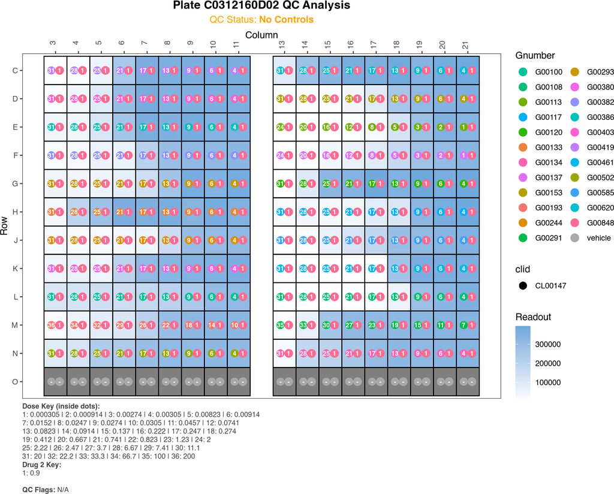

#### 3.4.1.2 C0112160D02

🔍 Zoom In for Details

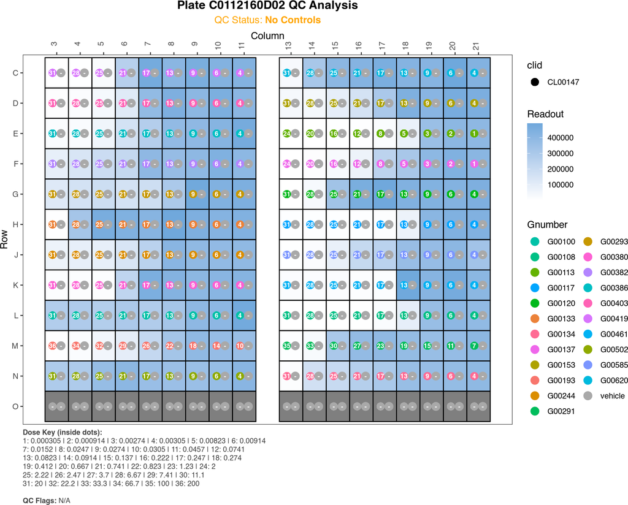

#### 3.4.1.3 C0312160D05

🔍 Zoom In for Details

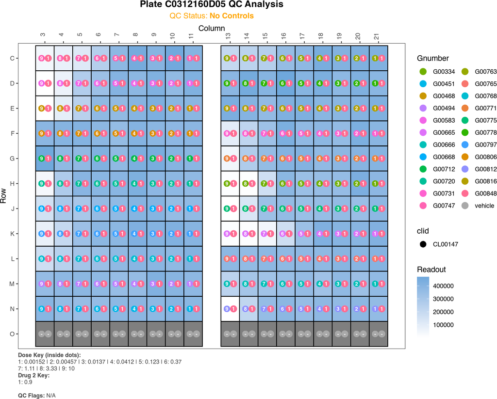

#### 3.4.1.4 C0112160D05

🔍 Zoom In for Details

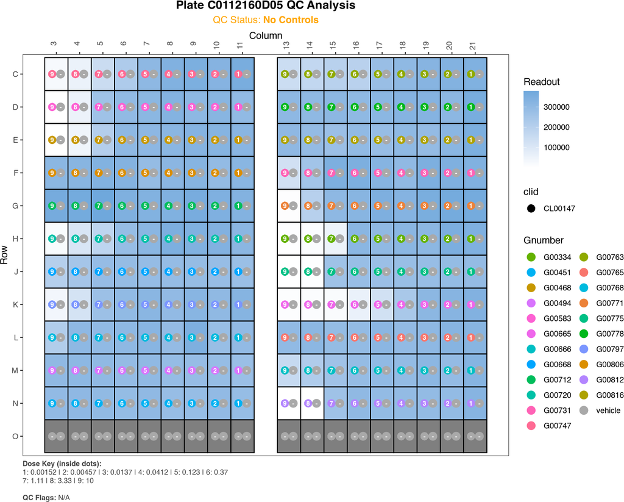

#### 3.4.1.5 C0312160D07

🔍 Zoom In for Details

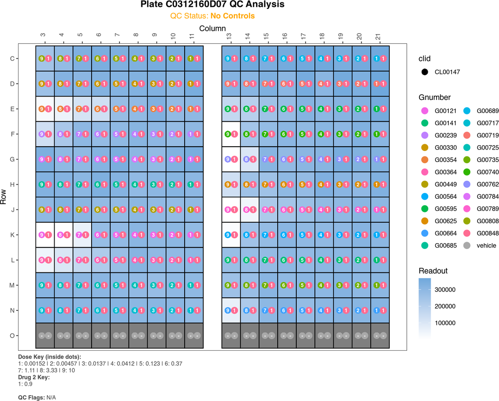

#### 3.4.1.6 C0112160D07

🔍 Zoom In for Details

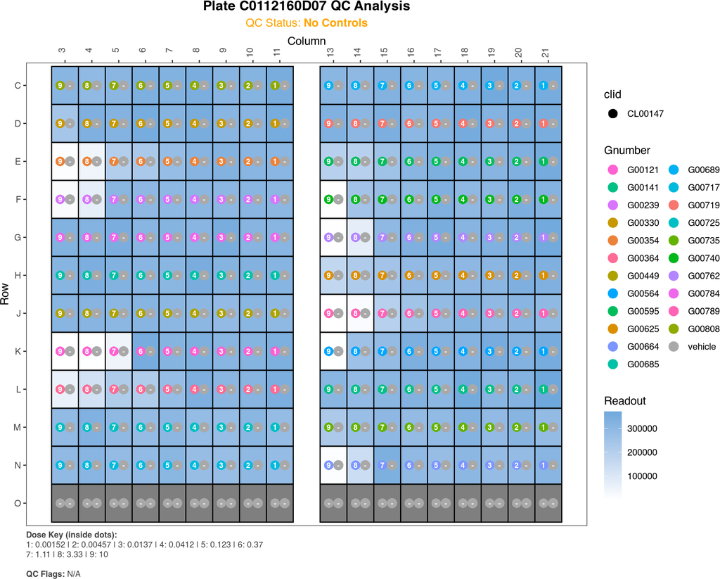

#### 3.4.1.7 C0312160D04

🔍 Zoom In for Details

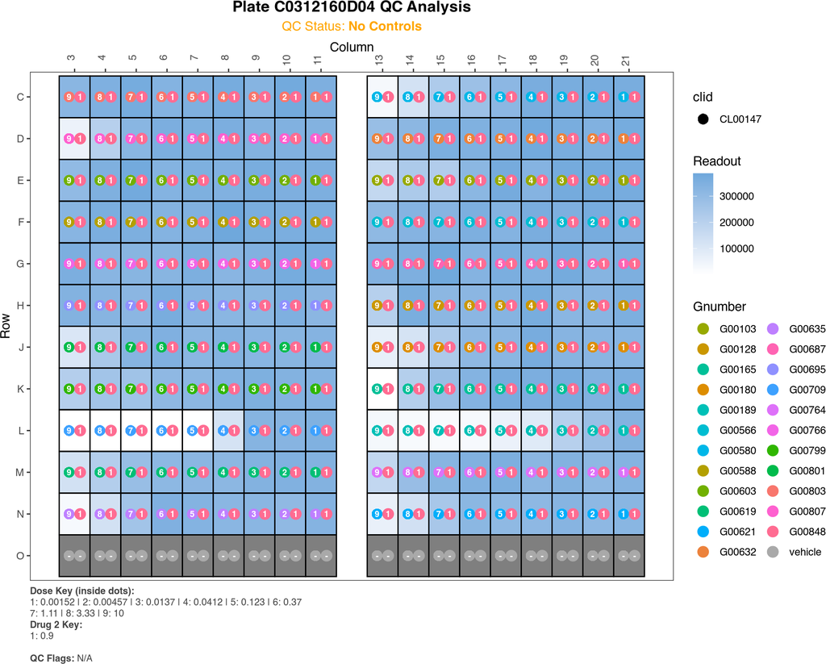

#### 3.4.1.8 C0112160D04

🔍 Zoom In for Details

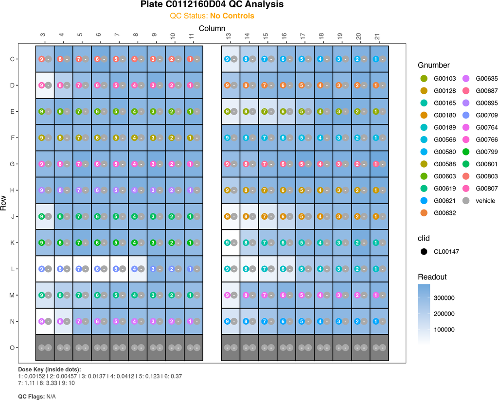

#### 3.4.1.9 C0312160D01

🔍 Zoom In for Details

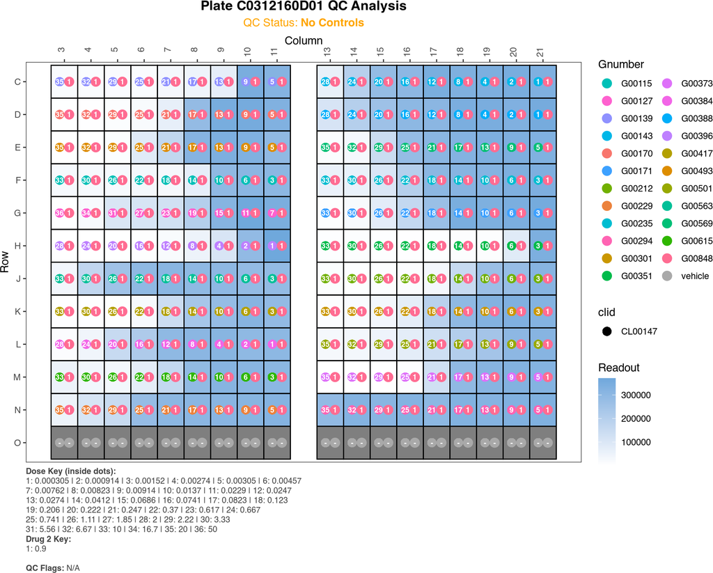

#### 3.4.1.10 C0112160D01

🔍 Zoom In for Details

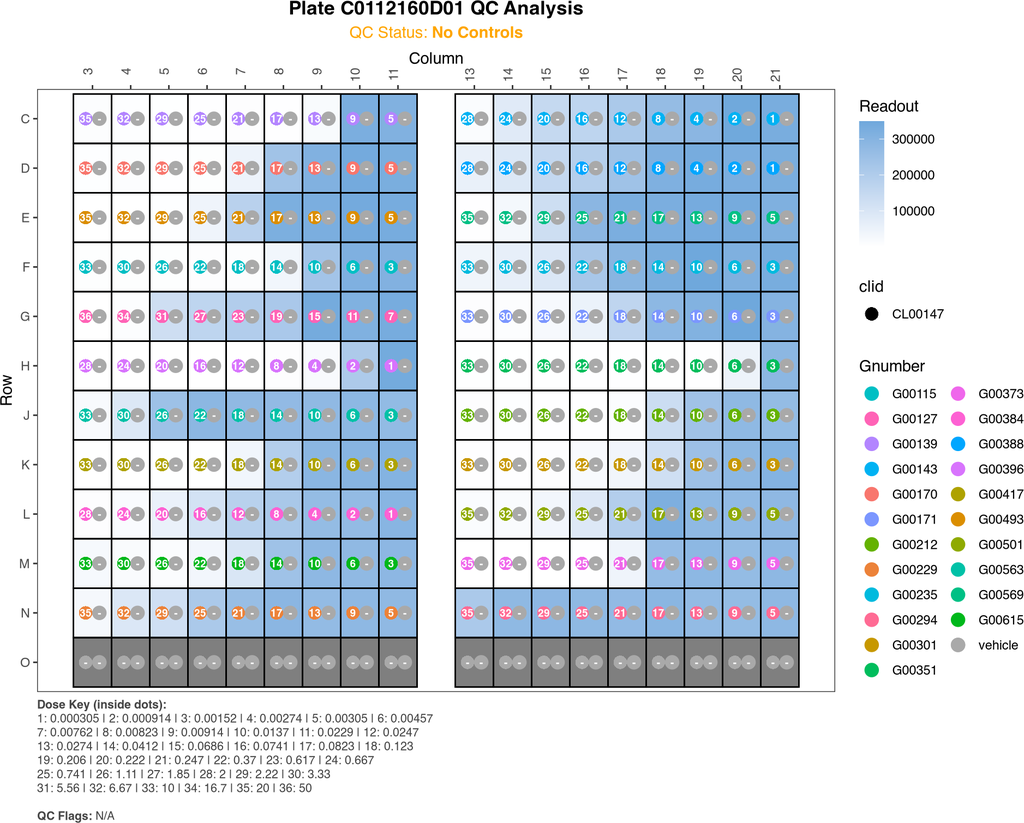

#### 3.4.1.11 C0312160D03

🔍 Zoom In for Details

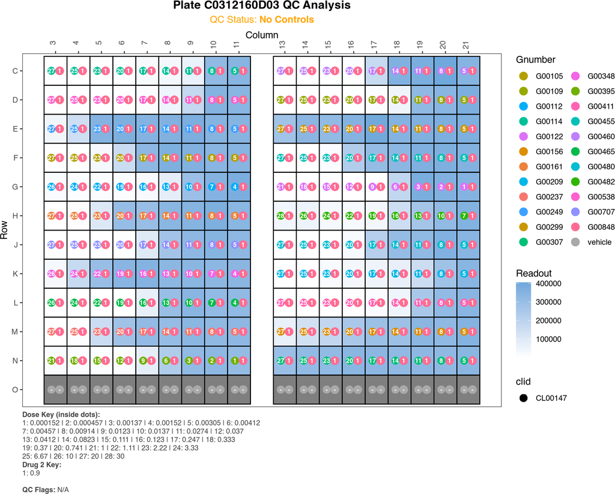

#### 3.4.1.12 C0112160D03

🔍 Zoom In for Details

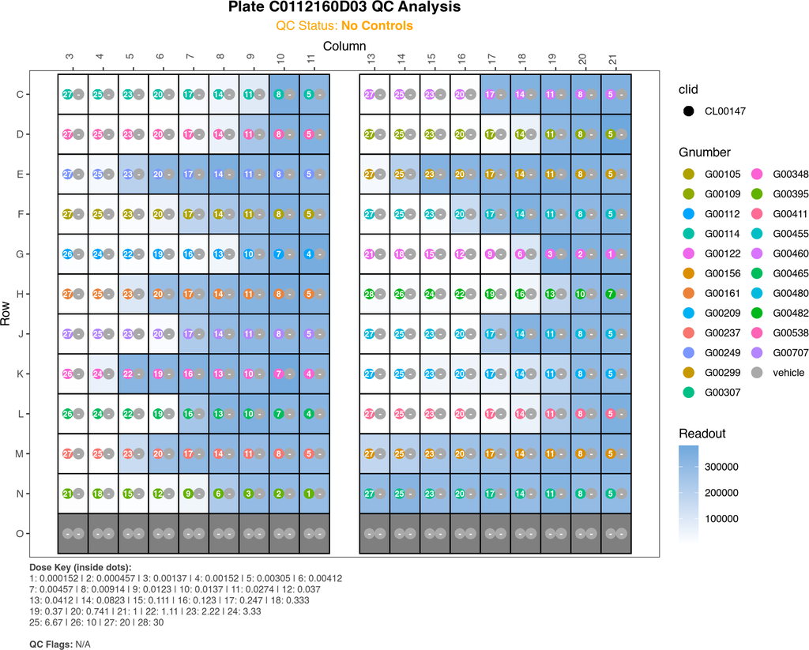

#### 3.4.1.13 C0312160D06

🔍 Zoom In for Details

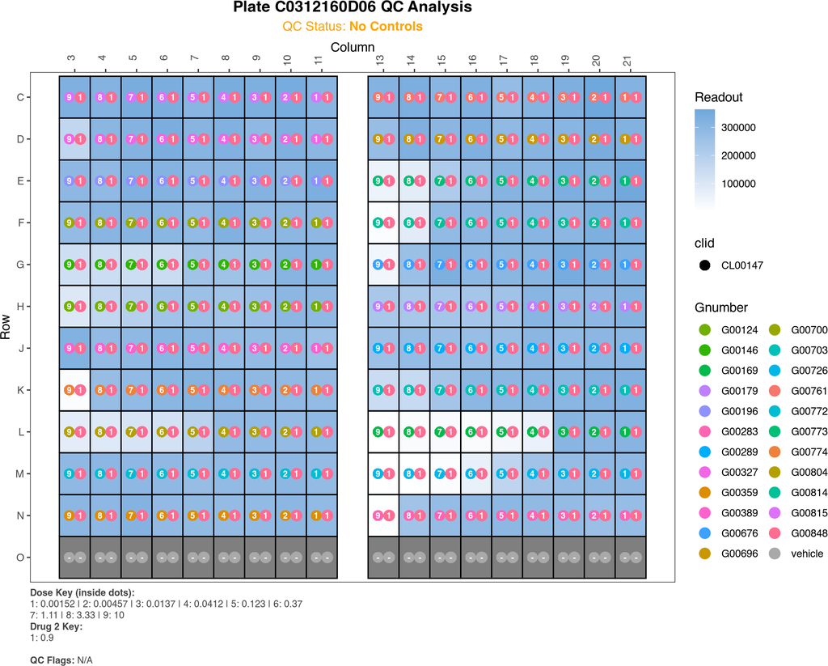

#### 3.4.1.14 C0112160D06

🔍 Zoom In for Details

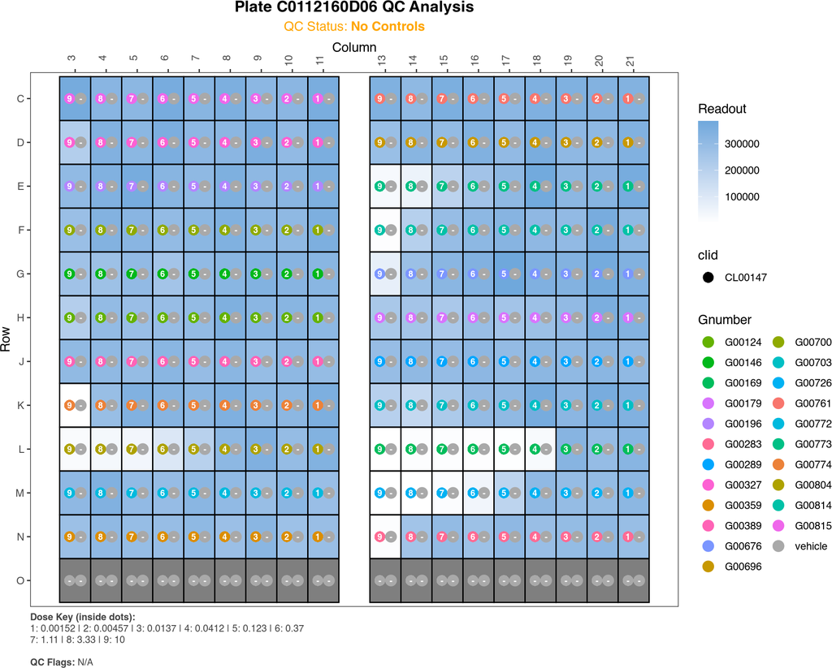

#### 3.4.1.15 C0312160D08

🔍 Zoom In for Details

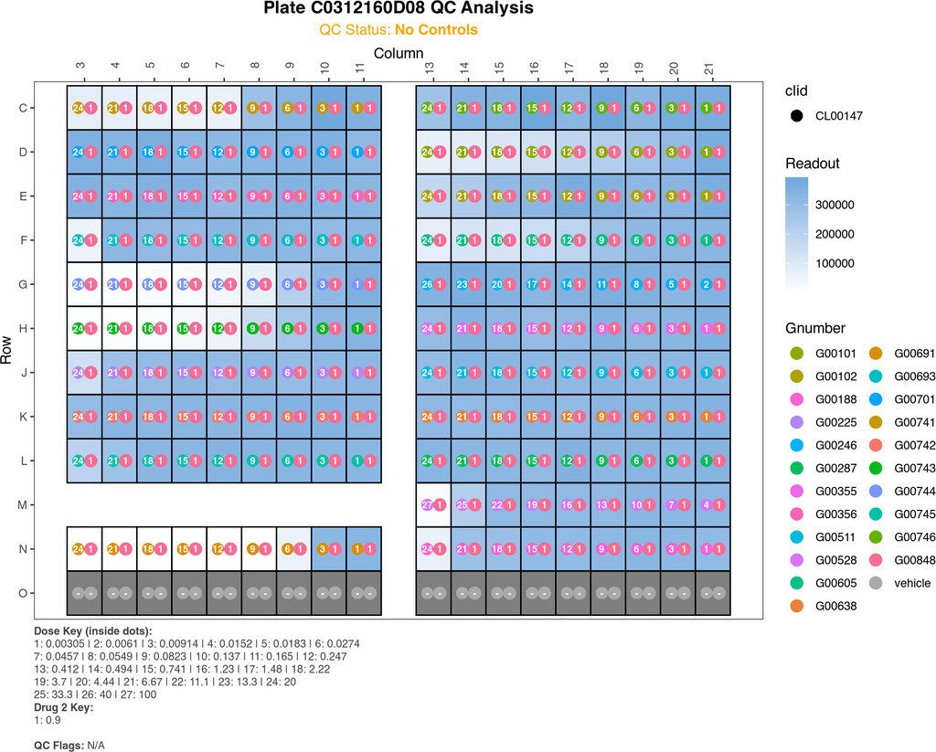

#### 3.4.1.16 C0112160D08

🔍 Zoom In for Details

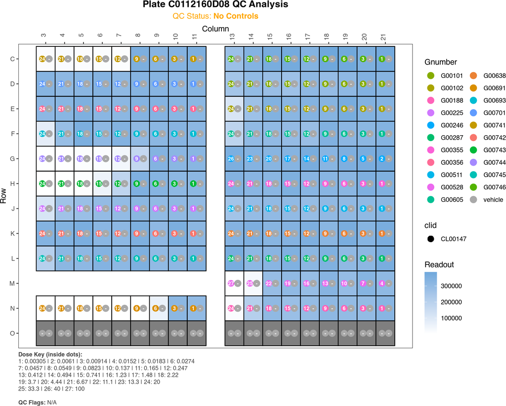

#### 3.4.1.17 C0701131D02

🔍 Zoom In for Details

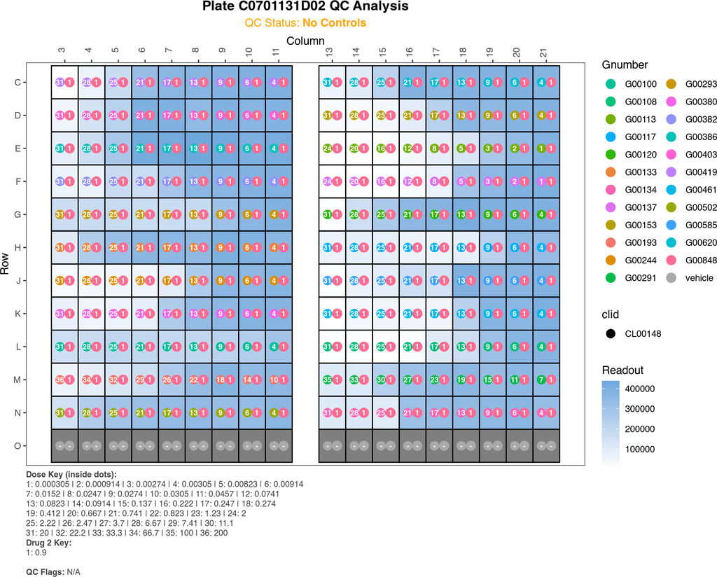

#### 3.4.1.18 C0501131D02

🔍 Zoom In for Details

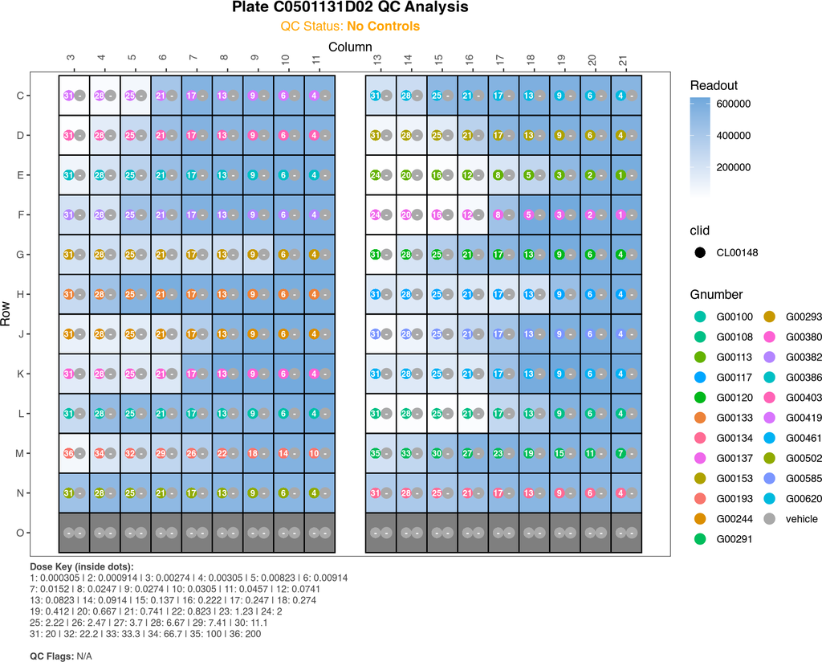

#### 3.4.1.19 C0701131D05

🔍 Zoom In for Details

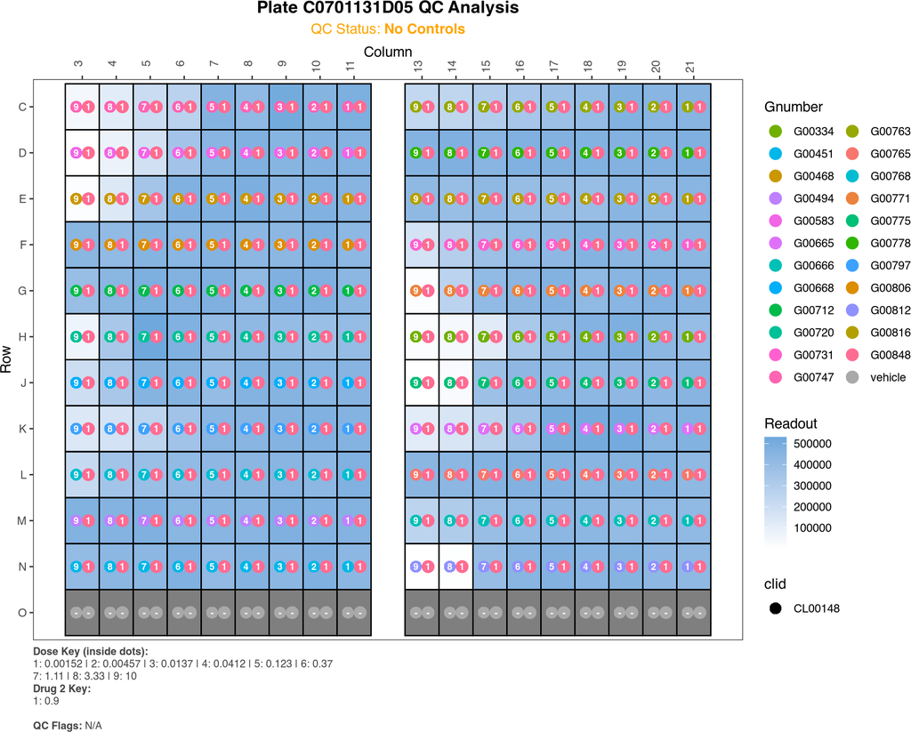

#### 3.4.1.20 C0501131D05

🔍 Zoom In for Details

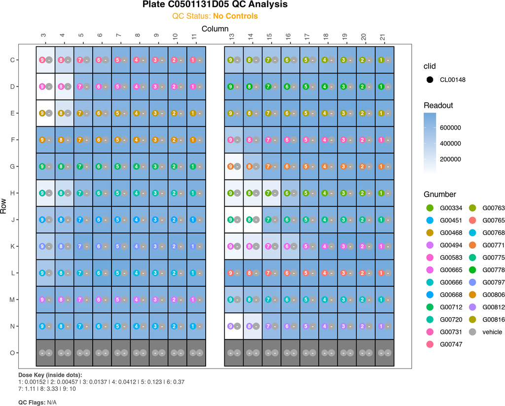

#### 3.4.1.21 C0701131D07

🔍 Zoom In for Details

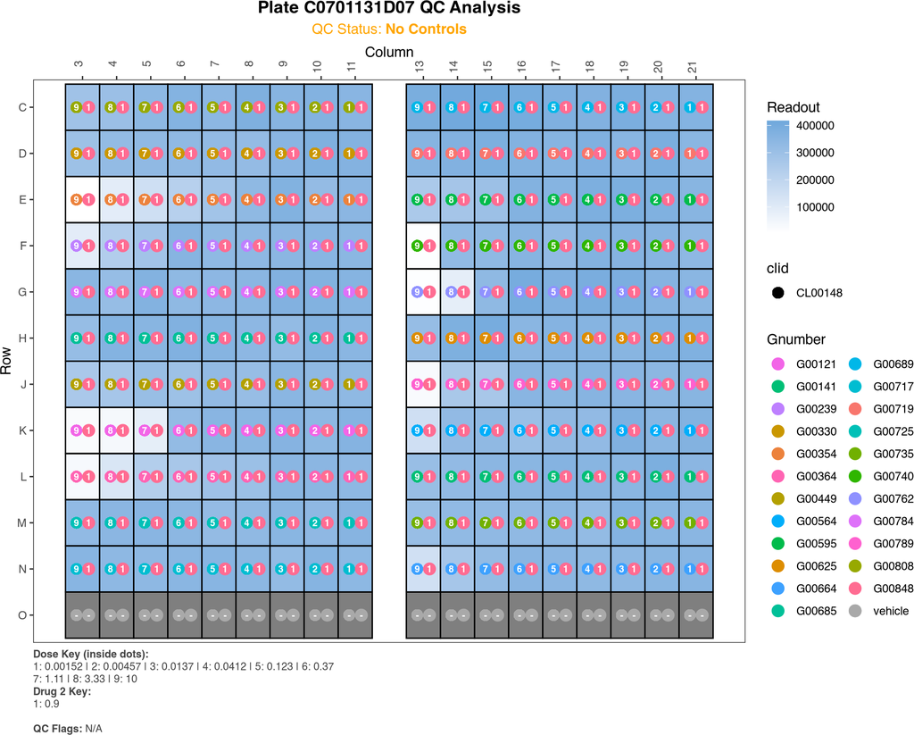

#### 3.4.1.22 C0501131D07

🔍 Zoom In for Details

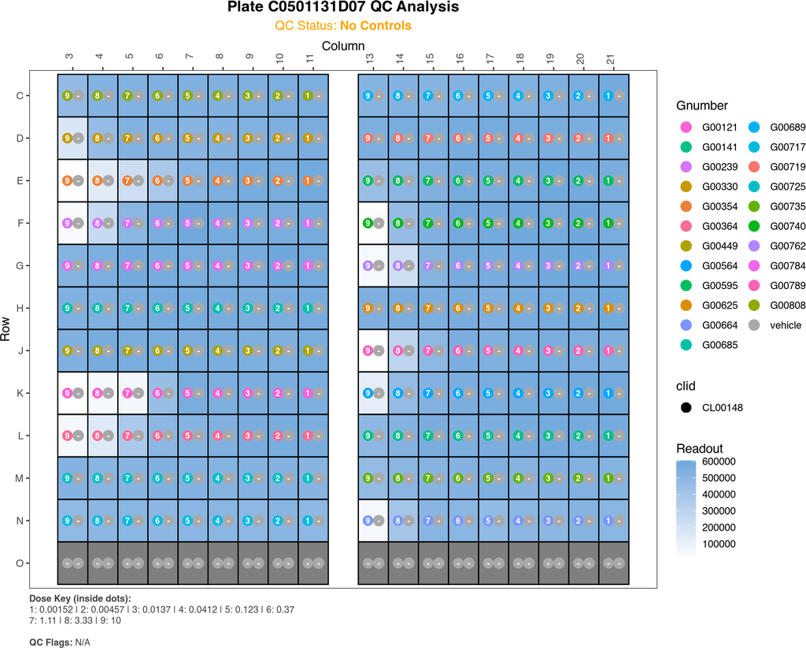

#### 3.4.1.23 C0701131D04

🔍 Zoom In for Details

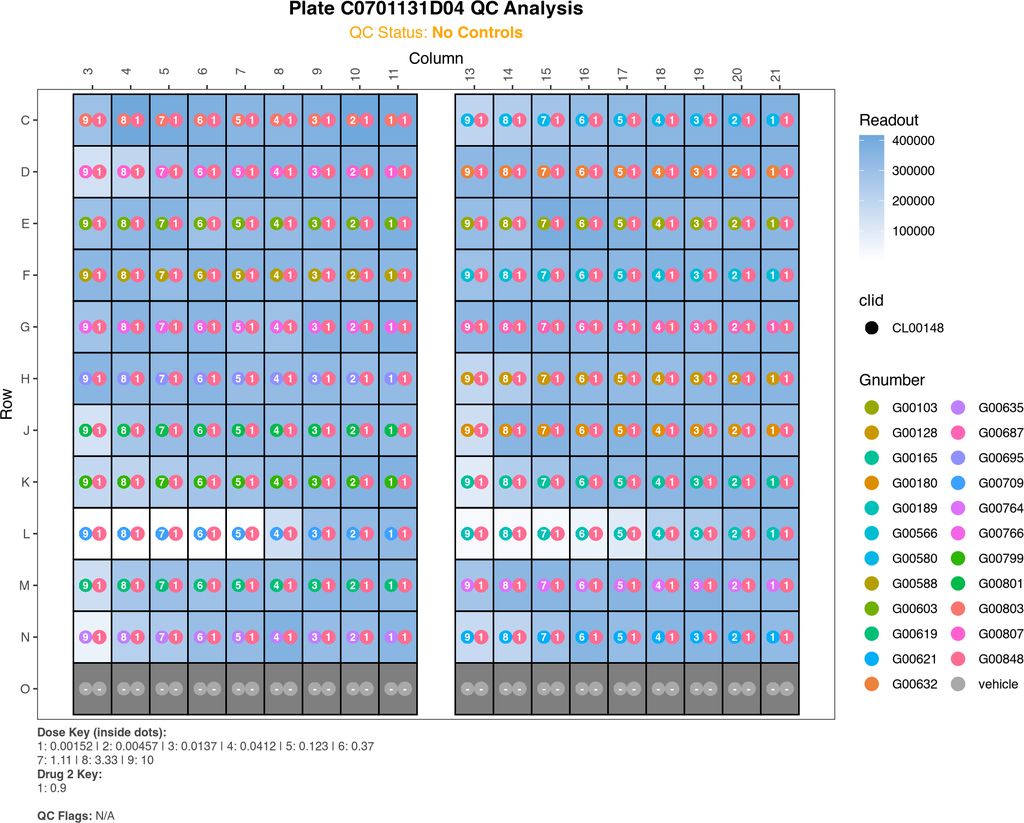

#### 3.4.1.24 C0501131D04

🔍 Zoom In for Details

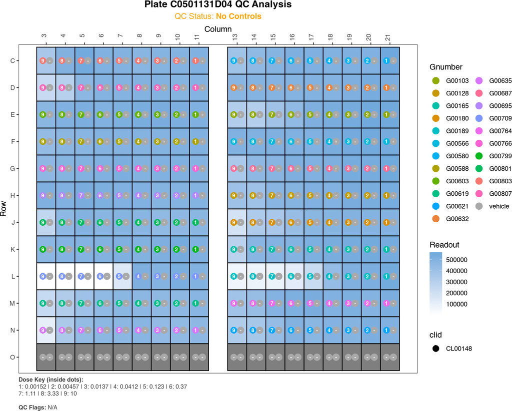

#### 3.4.1.25 C0701131D01

🔍 Zoom In for Details

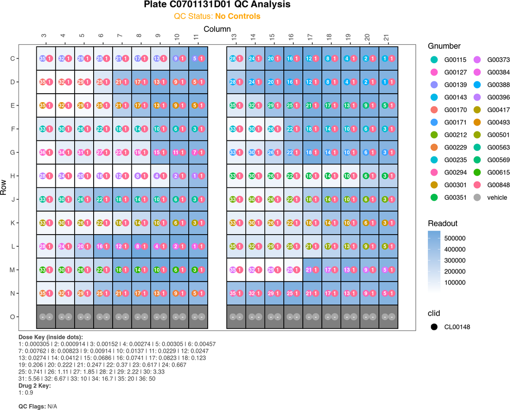

#### 3.4.1.26 C0501131D01

🔍 Zoom In for Details

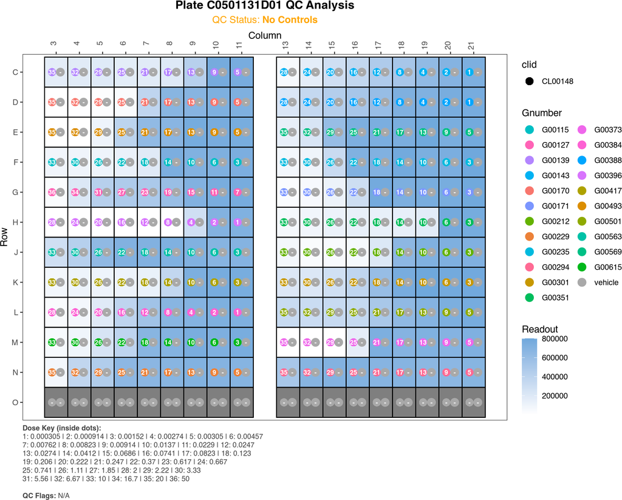

#### 3.4.1.27 C0701131D03

🔍 Zoom In for Details

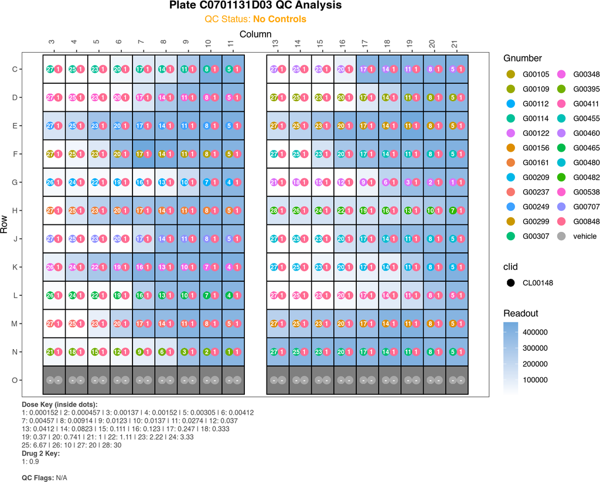

#### 3.4.1.28 C0501131D03

🔍 Zoom In for Details

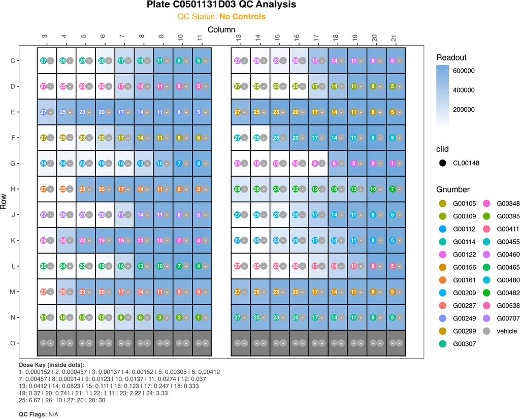

#### 3.4.1.29 C0701131D06

🔍 Zoom In for Details

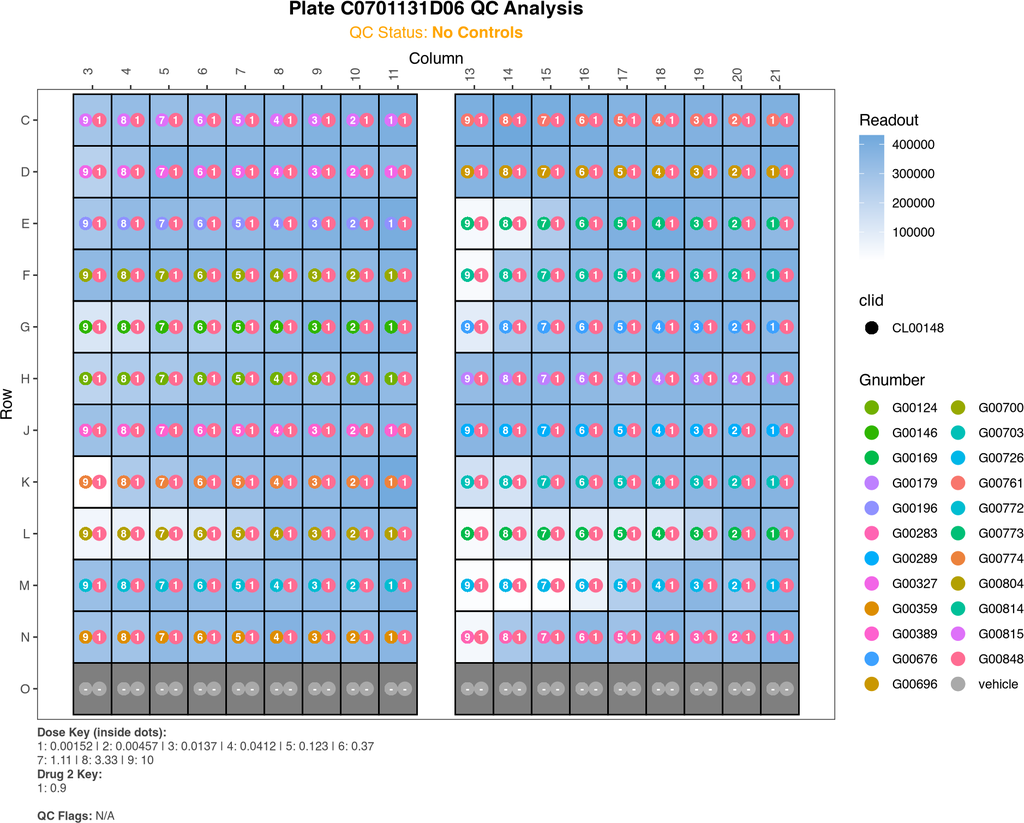

#### 3.4.1.30 C0501131D06

🔍 Zoom In for Details

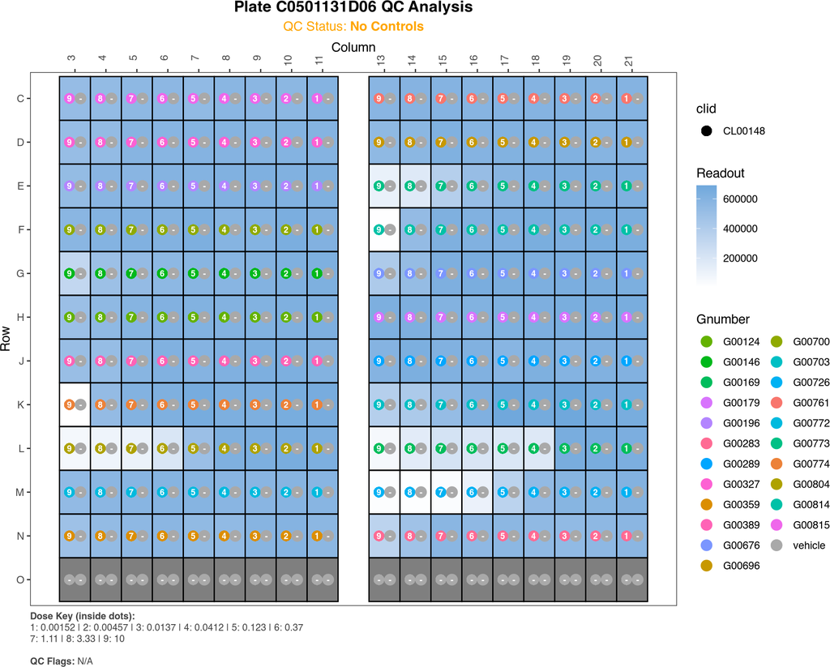

#### 3.4.1.31 C0701131D08

🔍 Zoom In for Details

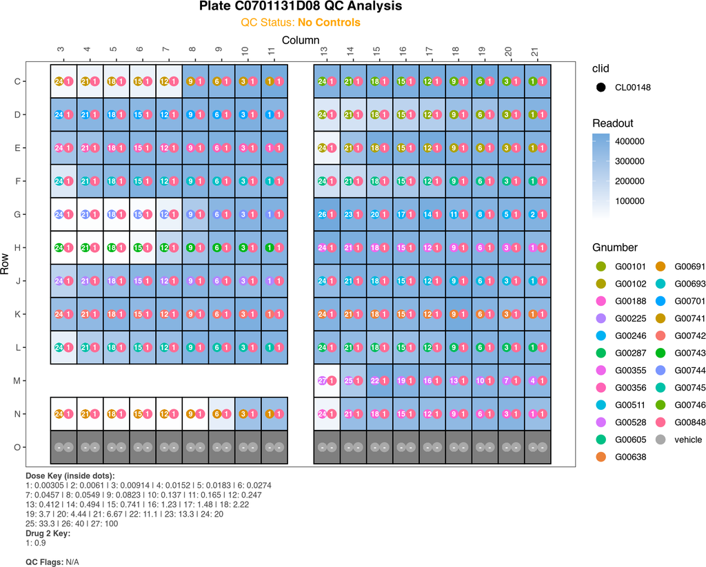